# Fusion, Fission, and Radioactive Decay — Student Worksheet

**Unit: Modern Physics — Lesson 05** Name: _______________________ Date: __________ Period: ____

## Phenomenon

A campfire burns out overnight. The **Sun** has blazed for about five billion years — and is barely halfway done. No chemical fire could last that long. The same word, *nuclear*, shows up in the Sun, in power plants, and in carbon-14 dating of ancient bones.

**Driving question:** Where does nuclear energy come from, why is it so enormous, and how does the nucleus change in each case?

## Notice & Wonder

| I notice… | I wonder… |
| --- | --- |

**Turn & Talk #1:** The same word — *nuclear* — covers the Sun, power plants, and carbon dating. Predict how the *nucleus* might change differently in each.

## Initial Model

Draw a nucleus (protons + neutrons). Show one way you think it could change to release energy.

> My idea: _______________________________

## Investigation

Rotate through the three stations. Use the figures below.

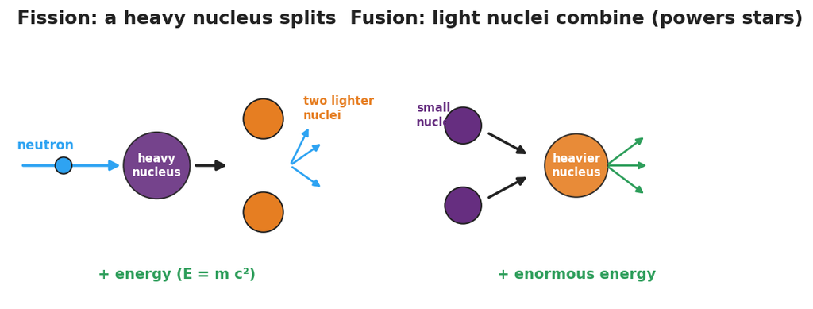

Side-by-side diagram: fission, where a neutron splits a heavy nucleus into two lighter nuclei plus more neutrons and energy; and fusion, where light nuclei combine into a heavier nucleus plus enormous energy.

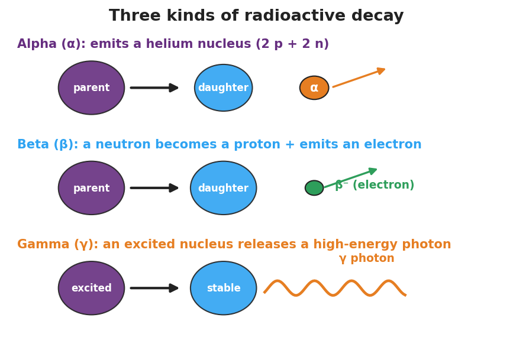

Diagram of alpha, beta, and gamma decay: alpha emits a helium nucleus, beta emits an electron as a neutron becomes a proton, and gamma releases a high-energy photon.

| Station | What happens to the nucleus? | Splits, combines, or emits? | Where do you see it in the real world? |
| --- | --- | --- | --- |
| 1. Fission |  |  |  |
| 2. Fusion |  |  |  |
| 3. Radioactive decay (α / β / γ) |  |  |  |

**Key question:** What do all three nuclear changes have in common?

## Make It Make Sense

1. A heavy uranium nucleus is hit by a neutron and breaks into two lighter nuclei. Is this fission, fusion, or decay? How do you know?
2. The Sun combines hydrogen nuclei into helium. Which process is this, and what does it have to do with how stars and elements form?
3. Why is the energy released by a nuclear change so much larger than the energy from burning fuel? (Use E = mc² as a *scale* idea — no calculation.)

## Vocabulary in Action

Use each term in a sentence about today’s phenomenon.

- **fission:** _______________________________________________
- **fusion:** _______________________________________________
- **radioactive decay:** _______________________________________________

## Revise Your Model

Return to your Initial Model. Redraw it as one of the three changes — fission, fusion, or decay — and label where the enormous energy comes from (mass → energy, E = mc², scale only).

## Exit Ticket

1. A heavy uranium nucleus is struck by a neutron and splits into two lighter nuclei. Is this fission, fusion, or decay?
2. The Sun combines hydrogen nuclei into helium. Which process is this, and what does it have to do with star formation?
3. Why is the energy from a nuclear change so much larger than the energy from burning fuel? (Use E = mc² as a scale idea — no calculation.)